# Introduction to Jupyter Notebook

Welcome to to the wonderful world of jupyter notebook. It is a "neat-o-rific" way of performing calculations and presenting results for scientists the world over!

Click on this "cell" to select it, then press Ctrl+Enter to "run" this cell.

# Types of Cells

## 1. Markdown

### 1.1 The Basics

- This is similar (in principle) to markup (i.e. HTML)
- Basic syntax (and only basic formatting)
  - **Bold** text is enclosed between a pair of **
  - *Italic* text is enclosed between a pair of *
  - Unordered lists start with a + or - (and can be nested, just use 4 or more spaces in front)
  - Links in parenthesis ( )

For more details see the [Github markdown reference](https://github.com/adam-p/markdown-here/wiki/Markdown-Cheatsheet)

### 1.2 Tables

A simple table

| Input size | Comparison Count |
| --- | --- |
| 100 | 205 |
| 200 | 1800 |
| 300 | 3200 |

### 1.3 Source code

Code may be written "inline" by enclosing it within a pair of backticks `

This is useful for small segments, like refering to the function `int SortAnalysis(auto)`.

Longer code segments should be "fenced" above and below with three ```

For C++ we put the name of the language after the first fence (like ```c++)

```
class Heap
   {

     private:
        vector<int> data = {};

     public:
         void insert(int);
         void heapifyDown(int);
         int deleteMin();
    };

    int main()
    {
       Heap pqueue;

       auto x = 13.75;

       for (auto z: {10, 14, 8, 12, 7, 20, 17})
       {
          pqueue.insert(z);
       }

     }
```

### 1.4 Math

Inline math can be written within a pair of \$ symbols \$. For example:

Algorithm `XYZ` is **clearly** $\Theta(n^2)$ in the worst case.

- \leq , \geq for $\leq$ , $\geq$

</br>

- \log n for $\log n$

</br>

- \sqrt{n+5} for $\sqrt{n+5}$

</br>

- ^{} for superscript (powers)
  - As an example $2^{2n}$

</br>

- _{} for subscript
  - As an example $\log_{2}n$

</br>

- \Theta, \Omega, O for $\Theta$, $\Omega$, and $O$

For math to be "set apart", it is enclosed in double \$\$.

For example \$\$ 2x \over \log(n^2) \$\$ will render as ...

$$ 2x \over \log(n^2)$$

Try writing some of your solutions to **§ 2.1 Q9** below

1. The function ... has a larger/smaller order of growth than ...
2. The function ... has a larger/smaller order of growth than ...

## 2. Code cells

These cells have the text **In[ ]** next to them and basically support *python* code directly

When executed, you will see the text **Out[ ]** immediately below the corresponding input cell

```python
# Code comments start with a '#
# python code

a = 7
b = 6

print('Hello jupyter\n\n-from python-\n\n')

print(a+b)
```

```
Hello jupyter

-from python-


13
```

### 2.1 Code Table

This is a more useful way of showing your data in tabular format if your data is in a `csv` file

First, we need to import required libraries

```python
# For plotting and other good stuff

import matplotlib.pyplot as plt  # Used for plotting
import numpy as np               # Extra features
import pandas as pd              # More, extra features
```

**NEXT**: Read the `csv` data from a file called `data.csv` (in the current folder)

```python
df = pd.read_csv('data.csv', index_col='size ') # This cell does not output anything when run (see below)
                                               # The data is stored in the object called df
```

```python
print(df)  # print df as plain text table
```

```
          Run1      Run2      Run3      Run4      Run5      Run6      Run7   \
size
1000     256352    257361    252662    245293    252518    245538    259505
1500     565044    554801    568838    554934    567905    567314    544232
2000    1013630    989099    963620   1016873   1012845    990815   1022071
2500    1549473   1561043   1586564   1539539   1582122   1554209   1543806
3000    2254895   2241892   2305853   2279715   2259956   2242343   2237505
3500    3025413   3067987   3035571   3048835   3065339   3092628   3147162
4000    3952266   3995087   3982366   3974685   3983351   3965461   4086375
4500    5151517   5136970   5088039   5093245   5128897   5130397   5043579
5000    6199968   6242346   6263048   6262625   6176489   6302697   6178821
5500    7491488   7562594   7722383   7661364   7498564   7553316   7611781
6000    8953671   9060798   9054023   9136892   9030042   8967691   8914570
6500   10644527  10641243  10640096  10633570  10479194  10678721  10478515
7000   12333129  12295634  12506022  12069900  12174420  12338794  12146565
```

[output cut: 47 more lines]

```python
df  # print df as pretty  table
```

| size | Run1 | Run2 | Run3 | Run4 | Run5 | Run6 | Run7 | Run8 | Run9 | Run10 | Run11 | Run12 | Run13 | Run14 | Run15 | Run16 | Run17 | Run18 | Run19 | Run20 |
| --- | --- | --- | --- | --- | --- | --- | --- | --- | --- | --- | --- | --- | --- | --- | --- | --- | --- | --- | --- | --- |
| 1000 | 256352 | 257361 | 252662 | 245293 | 252518 | 245538 | 259505 | 232459 | 261136 | 260299 | 245246 | 249187 | 246952 | 255838 | 246323 | 254402 | 248522 | 240087 | 248070 | 251976 |
| 1500 | 565044 | 554801 | 568838 | 554934 | 567905 | 567314 | 544232 | 560299 | 569025 | 572175 | 570501 | 578305 | 555254 | 553336 | 579708 | 554968 | 568795 | 565043 | 565069 | 567883 |
| 2000 | 1013630 | 989099 | 963620 | 1016873 | 1012845 | 990815 | 1022071 | 985823 | 1005862 | 1013151 | 992813 | 975332 | 996424 | 1003165 | 1031619 | 1001227 | 998299 | 984761 | 1034466 | 992777 |
| 2500 | 1549473 | 1561043 | 1586564 | 1539539 | 1582122 | 1554209 | 1543806 | 1576520 | 1562952 | 1580750 | 1564463 | 1502955 | 1586266 | 1529918 | 1545066 | 1580201 | 1578766 | 1550296 | 1548359 | 1575709 |
| 3000 | 2254895 | 2241892 | 2305853 | 2279715 | 2259956 | 2242343 | 2237505 | 2238234 | 2249177 | 2256887 | 2286659 | 2274245 | 2244137 | 2236330 | 2282204 | 2222765 | 2239486 | 2291336 | 2251709 | 2227801 |
| 3500 | 3025413 | 3067987 | 3035571 | 3048835 | 3065339 | 3092628 | 3147162 | 3112133 | 3016089 | 3032746 | 3080374 | 3054468 | 3100280 | 3085196 | 3041457 | 3097042 | 2985728 | 3001885 | 3022243 | 3006223 |
| 4000 | 3952266 | 3995087 | 3982366 | 3974685 | 3983351 | 3965461 | 4086375 | 3941233 | 3946875 | 3970963 | 4090850 | 4037171 | 3987701 | 3954194 | 4024706 | 4016903 | 3975804 | 3998759 | 4023232 | 4027457 |
| 4500 | 5151517 | 5136970 | 5088039 | 5093245 | 5128897 | 5130397 | 5043579 | 5156320 | 5058966 | 5188055 | 4950935 | 5001742 | 5049639 | 4993806 | 5089082 | 5018214 | 5041194 | 5072477 | 5096376 | 4994444 |
| 5000 | 6199968 | 6242346 | 6263048 | 6262625 | 6176489 | 6302697 | 6178821 | 6222286 | 6182946 | 6342704 | 6256800 | 6275356 | 6089236 | 6206645 | 6259170 | 6290689 | 6263227 | 6203311 | 6269004 | 6237778 |
| 5500 | 7491488 | 7562594 | 7722383 | 7661364 | 7498564 | 7553316 | 7611781 | 7501820 | 7674705 | 7580695 | 7559301 | 7605485 | 7659740 | 7647246 | 7548572 | 7599778 | 7668441 | 7639935 | 7497906 | 7607327 |
| 6000 | 8953671 | 9060798 | 9054023 | 9136892 | 9030042 | 8967691 | 8914570 | 8955348 | 9050196 | 8977648 | 9070217 | 9040045 | 9035452 | 8921199 | 8914693 | 9138289 | 8898254 | 8960592 | 9100165 | 8985167 |
| 6500 | 10644527 | 10641243 | 10640096 | 10633570 | 10479194 | 10678721 | 10478515 | 10621333 | 10500213 | 10600418 | 10581002 | 10688400 | 10619133 | 10673151 | 10460985 | 10488791 | 10503698 | 10532654 | 10503670 | 10439461 |
| 7000 | 12333129 | 12295634 | 12506022 | 12069900 | 12174420 | 12338794 | 12146565 | 12233029 | 12344484 | 12310634 | 12178322 | 12253693 | 12176678 | 12323223 | 12268395 | 12309105 | 12289373 | 12228811 | 12188897 | 12314407 |
| 7500 | 14158908 | 13993575 | 14050510 | 13900988 | 14175216 | 14026897 | 13998380 | 14078700 | 14058332 | 14097058 | 14018173 | 14289607 | 13962100 | 14151498 | 14104615 | 14107813 | 14117534 | 14247602 | 14134135 | 14080755 |
| 8000 | 15845065 | 16021548 | 16073305 | 16111846 | 15897376 | 16144418 | 15954620 | 16111483 | 16139883 | 16146560 | 15942335 | 16033643 | 16128200 | 16137871 | 16009348 | 15961734 | 15976297 | 15992392 | 16084404 | 15805545 |
| 8500 | 17923398 | 17912103 | 18078780 | 18044666 | 18137018 | 18166678 | 18176749 | 18040031 | 17848273 | 18095700 | 18033522 | 18224183 | 18258535 | 18110975 | 18032715 | 18224550 | 18080892 | 18203919 | 18081214 | 18029146 |
| 9000 | 20226744 | 20361046 | 20045661 | 20017978 | 20341844 | 20663629 | 20036689 | 20321068 | 20225786 | 20225242 | 20261208 | 20288381 | 20555656 | 20413653 | 20248229 | 20476517 | 20154084 | 20236055 | 20318671 | 20265541 |
| 9500 | 22513233 | 22716835 | 22486783 | 22563586 | 22123180 | 22300118 | 22671098 | 22279604 | 22389405 | 22471385 | 22520800 | 22375795 | 22553968 | 22547288 | 22630362 | 22416670 | 22537728 | 22934377 | 22445402 | 22592223 |

### 2.1 Plotting graphs

```python
plt_x = [x for x in df.index ]                      # prepare data for x axis
plt_y = [df.loc[y].mean(axis=0) for y in plt_x]     # prepare data for y axis
```

```python
print('X axis data')
print (plt_x)
print('\n\nY axis data')
print(plt_y)
```

[output not shown]

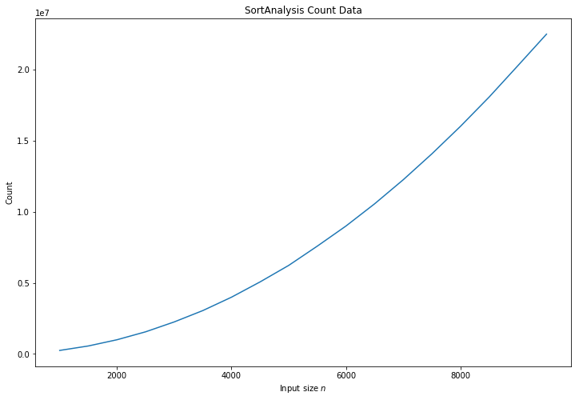

```python
fig = plt.figure(figsize=(12,8))
axes = fig.add_subplot(111) # 111 means working with one chart (whatever that means!!)

axes.plot(plt_x,plt_y)
axes.set_title('SortAnalysis Count Data')
axes.set_xlabel('Input size $n$')
axes.set_ylabel('Count')
plt.show()
```

### Comparing plots

1. Generate linear and quadratic y values (based on the original `plt_x` data)
2. Plot all data on the same figure

```python
linear_y = plt_x                       # every y value is the same as every x value in plt_x
quadratic_y = [y*y for y in plt_x]     # the square of every x value in plt_x
cubic_y = [y*y*y for y in plt_x]
```

[output not shown]

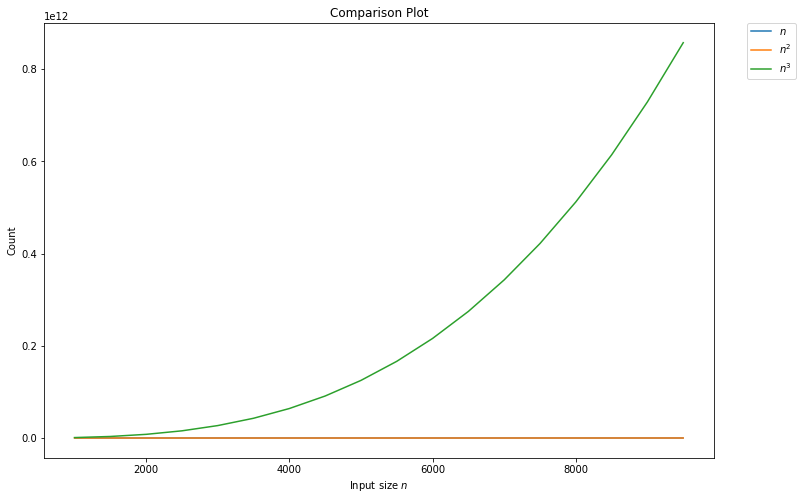

```python
fig2 = plt.figure(figsize=(12,8))
axes = fig2.add_subplot(111) # 111 means working with one chart (whatever that means!!)

axes.plot(plt_x, linear_y, label = '$n$')  #added labels to each plot
axes.plot(plt_x, quadratic_y, label = '$n^2$')
axes.plot(plt_x, cubic_y,  label = '$n^3$')
# Place a legend to the right of this smaller subplot.
plt.legend(bbox_to_anchor=(1.05, 1), loc=2, borderaxespad=0.)

axes.set_title('Comparison Plot')
axes.set_xlabel('Input size $n$')
axes.set_ylabel('Count')
#plt.show()              # What??? This line isn't needed???????
```